# STAT 432 Homework 05

Kevin Wong - kjwong2

Due:** Friday, March 2, 11:59 PM

Please see the [homework policy document](https://daviddalpiaz.github.io/stat432sp18/homework_policy.html) for detailed instructions and some grading notes. Failure to follow instructions will result in point reductions.

> “Our greatest glory is not in never falling, but in rising every time we fall.”

> — **Confucius**

For this homework, you may only use the following packages:

```r
# general
library(MASS)
library(caret)
library(tidyverse)
library(knitr)
library(kableExtra)

# specific
library(e1071)
library(nnet)
library(ellipse)
```

If you feel additional general packages would be useful for future homework, please pass these along to the instructor.

# Exercise 1 (Detecting Cancer with KNN)

**[6 points]** For this exercise we will use data found in `wisc-trn.csv` and `wisc-tst.csv` which contain train and test data respectively. `wisc.csv` is provided but not used. This is a modification of the Breast Cancer Wisconsin (Diagnostic) dataset from the UCI Machine Learning Repository. Only the first 10 feature variables have been provided. (And these are all you should use.)

- UCI Page
- [Data Detail](https://archive.ics.uci.edu/ml/machine-learning-databases/breast-cancer-wisconsin/wdbc.names)

You should consider coercing the response to be a factor variable.

Consider two different preprocessing setups:

- **Setup 1**
  - Numeric variables not scaled.
- **Setup 2**
  - Numeric variables are scaled to have mean 0 and standard deviation 1.

For each setup, train KNN models using values of `k` from `1` to `50`. Using only the variables `radius`, `symmetry`, and `texture`. For each, calculate test classification error. Summarize these results in a single plot which plots the test error as a function of `k`. (The plot will have two “curves,” one for each setup.) Your plot should be reasonably visually appealing, well-labeled, and include a legend.

**Answer:**

```r
wisc_trn_data = read.csv("wisc-trn.csv")
wisc_tst_data = read.csv("wisc-tst.csv")
```

```r
set.seed(10)
calc_class_err = function(actual, predicted) {
  mean(actual != predicted)
}

k_seq = 1:200
class_err_mod_1 = 1:200
class_err_mod_2 = 1:200
for (i in 1:200){
  knn_tst_mod_1 = knn3(class ~ radius + symmetry + texture, data = wisc_trn_data, k = i)
  knn_tst_mod_2 = knn3(class ~ scale(radius) + scale(symmetry) + scale(texture), data = wisc_trn_data, k = i)

  predictions_1 = predict(knn_tst_mod_1, newdata = wisc_tst_data, type = "class")
  predictions_2 = predict(knn_tst_mod_2, newdata = wisc_tst_data, type = "class")

  class_err_mod_1[i] = calc_class_err(actual = wisc_tst_data$class, predicted = predictions_1)
  class_err_mod_2[i] = calc_class_err(actual = wisc_tst_data$class, predicted = predictions_2)
}
```

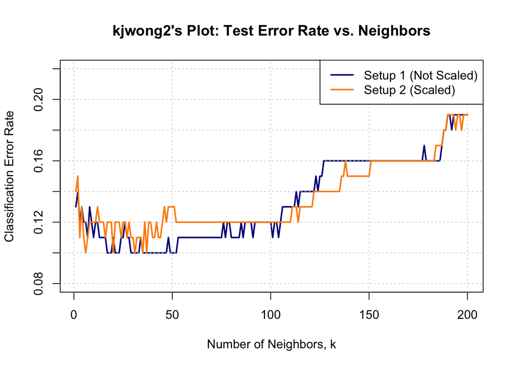

# Exercise 2 (Bias-Variance Tradeoff, Logistic Regression)

**[9 points]** Run a simulation study to estimate the bias, variance, and mean squared error of estimating $p(x)$ using logistic regression. Recall that $p(x) = P(Y = 1 \mid X = x)$.

Consider the (true) logistic regression model

$$\log \left( \frac{p(x)}{1 - p(x)} \right) = 1 + 2 x_1 - x_2$$

To specify the full data generating process, consider the following `R` function.

```r
make_sim_data = function(n_obs = 100) {
  x1 = runif(n = n_obs, min = 0, max = 2)
  x2 = runif(n = n_obs, min = 0, max = 4)
  prob = exp(1 + 2 * x1 - 1 * x2) / (1 + exp(1 + 2 * x1 - 1 * x2))
  y = rbinom(n = n_obs, size = 1, prob = prob)
  data.frame(y, x1, x2)
}
```

So, the following generates one simulated dataset according to the data generating process defined above.

```r
sim_data = make_sim_data()
```

Evaluate estimates of $p(x_1 = 0.5, x_2 = 0.75)$ from fitting four models:

$$\log \left( \frac{p(x)}{1 - p(x)} \right) = \beta_0$$

$$\log \left( \frac{p(x)}{1 - p(x)} \right) = \beta_0 + \beta_1 x_1 + \beta_2 x_2$$

$$\log \left( \frac{p(x)}{1 - p(x)} \right) = \beta_0 + \beta_1 x_1 + \beta_2 x_2 + \beta_3 x_1x_2$$

$$\log \left( \frac{p(x)}{1 - p(x)} \right) = \beta_0 + \beta_1 x_1 + \beta_2 x_2 + \beta_3 x_1^2 + \beta_4 x_2^2 + \beta_5 x_1x_2$$

Use `2000` simulations of datasets with a sample size of `30` to estimate squared bias, variance, and the mean squared error of estimating $p(x_1 = 0.5, x_2 = 0.75)$ using $\hat{p}(x_1 = 0.5, x_2 = 0.75)$ for each model. Report your results using a well formatted table.

At the beginning of your simulation study, run the following code, but with your nine-digit Illinois UIN.

```r
set.seed(665065175)
```

**Answer:**

```r
n_sims = 2000
n_models = 4
x = data.frame(x1 = 0.5, x2 = 0.75)
predictions_ex2 = matrix(0, nrow = n_sims, ncol = n_models)
```

```r
for(i in 1:n_sims) {
  sim_data = make_sim_data()

  ex2_model_1_intcept = glm(y ~ 1, data = sim_data, family = "binomial")
  ex2_model_2_add = glm(y ~ x1 + x2, data = sim_data, family = "binomial")
  ex2_model_3_inter = glm(y ~ x1 * x2, data = sim_data, family = "binomial")
  ex2_model_4_quad = glm(y ~ x1 * x2 + I(x1 ^ 2) + I(x2 ^ 2), data = sim_data, family = "binomial")

  predictions_ex2[i, 1] = predict(ex2_model_1_intcept, x, type = "response")
  predictions_ex2[i, 2] = predict(ex2_model_2_add, x, type = "response")
  predictions_ex2[i, 3] = predict(ex2_model_3_inter, x, type = "response")
  predictions_ex2[i, 4] = predict(ex2_model_4_quad, x, type = "response")
}
```

```r
get_mse = function(truth, estimate) {
  mean((estimate - truth) ^ 2)
}

get_bias = function(estimate, truth) {
  mean(estimate) - truth
}

get_var = function(estimate) {
  mean((estimate - mean(estimate)) ^ 2)
}
```

```r
p = function(x) {
  with(x,
       exp(1 + 2 * x1 - 1 * x2) / (1 + exp(1 + 2 * x1 - 1 * x2))
  )
}

p(x = x)
```

```
## [1] 0.7772999
```

| Logistic Regression Model | Mean Squared Error | Bias Squared | Variance |
| --- | --- | --- | --- |
| Intercept Only | 0.0158477 | 0.0134838 | 0.0023639 |
| Additive | 0.0063253 | 0.0000000 | 0.0063253 |
| Interaction | 0.0075162 | 0.0000078 | 0.0075084 |
| Second Order | 0.0096843 | 0.0000681 | 0.0096162 |

# Exercise 3 (Comparing Classifiers)

**[8 points]** Use the data found in `hw05-trn.csv` and `hw05-tst.csv` which contain train and test data respectively. Use `y` as the response. Coerce `y` to be a factor after importing the data if it is not already.

Create a pairs plot with ellipses for the training data, then train the following models using both available predictors:

- Additive Logistic Regression (Multinomial Regression)
- LDA (with Priors estimated from data)
- LDA with Flat Prior
- QDA (with Priors estimated from data)
- QDA with Flat Prior
- Naive Bayes (with Priors estimated from data)

Calculate test and train error rates for each model. Summarize these results using a single well-formatted table.

**Answer:**

```r
hw05_trn_data = read.csv("hw05-trn.csv")
hw05_tst_data = read.csv("hw05-tst.csv")
```

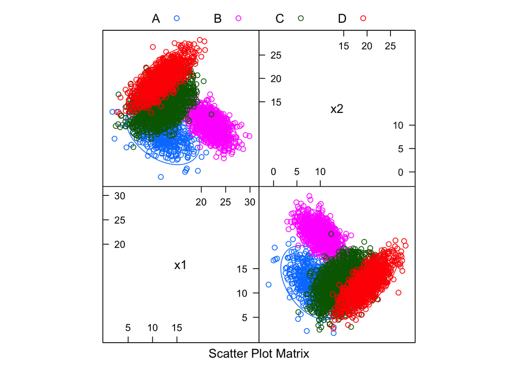

```r
flat = c(1, 1, 1, 1) / 4

trn_err_rates = c(
  calc_class_err(hw05_trn_data$y, predict(multinom(y ~ x1 + x2, hw05_trn_data, trace = FALSE), hw05_trn_data)),
  calc_class_err(hw05_trn_data$y, predict(lda(y ~ x1 + x2, hw05_trn_data), hw05_trn_data)$class),
  calc_class_err(hw05_trn_data$y, predict(lda(y ~ x1 + x2, hw05_trn_data, prior = flat), hw05_trn_data)$class),
  calc_class_err(hw05_trn_data$y, predict(qda(y ~ x1 + x2, hw05_trn_data), hw05_trn_data)$class),
  calc_class_err(hw05_trn_data$y, predict(qda(y ~ x1 + x2, hw05_trn_data, prior = flat), hw05_trn_data)$class),
  calc_class_err(hw05_trn_data$y, predict(naiveBayes(y ~ x1 + x2, hw05_trn_data), hw05_trn_data))
)

tst_err_rates = c(
  calc_class_err(hw05_tst_data$y, predict(multinom(y ~ x1 + x2, hw05_trn_data, trace = FALSE), hw05_tst_data)),
  calc_class_err(hw05_tst_data$y, predict(lda(y ~ x1 + x2, hw05_trn_data), hw05_tst_data)$class),
  calc_class_err(hw05_tst_data$y, predict(lda(y ~ x1 + x2, hw05_trn_data, prior = flat), hw05_tst_data)$class),
  calc_class_err(hw05_tst_data$y, predict(qda(y ~ x1 + x2, hw05_trn_data), hw05_tst_data)$class),
  calc_class_err(hw05_tst_data$y, predict(qda(y ~ x1 + x2, hw05_trn_data, prior = flat), hw05_tst_data)$class),
  calc_class_err(hw05_tst_data$y, predict(naiveBayes(y ~ x1 + x2, hw05_trn_data), hw05_tst_data))
)
```

| Method | Training Error Rate | Testing Error Rate |
| --- | --- | --- |
| Logistic (Multinomial) | 0.1482 | 0.1742 |
| LDA | 0.1620 | 0.1982 |
| LDA, Flat Prior | 0.1907 | 0.1688 |
| QDA | 0.1478 | 0.1693 |
| QDA, Flat Prior | 0.1791 | 0.1400 |
| Naive Bayes | 0.1733 | 0.2000 |

# Exercise 4 (Concept Checks)

**[1 point each]** Answer the following questions based on your results from the previous three exercises.

**(a)** Based on your results in Exercise 2, which models are performing unbiased estimation?

**Answer:** The additive, interactive, and the second order quadratic models.

**(b)** Based on your results in Exercise 2, which of these models performs best?

**Answer:** The additive model performs best because it has the lowest Mean Squared Error.

**(c)** In Exercise 3, which model performs best?

**Answer:** The QDA with a Flat Prior performs best because it has the lowest Testing Classification Error Rate.

**(d)** In Exercise 3, why does Naive Bayes perform poorly?

**Answer:** Naive Bayes assumes that the covarience between the predictors is 0 (the correlation between the predictors is 0). However, from looking at the plots, there seems to be a correlation between `x1` and `x2` in all classes.

**(e)** In Exercise 3, which performs better, LDA or QDA? Why?

**Answer:** QDA is better because we can see that the correlation matrix ($\Sigma_k$) is different for different classes.

**(f)** In Exercise 3, which prior performs better? Estimating from data, or using a flat prior? Why?

**Answer:** The flat prior is better because for this dataset, the proportion of data in the levels of `y` is equal.

**(g)** In Exercise 3, of the four classes, which is the easiest to classify?

**Answer:**

```r
tst_table = table(Predicted = predict(qda(y ~ ., data = hw05_trn_data, prior = flat), hw05_tst_data)$class, Actual = hw05_tst_data$y)
tst_table
```

```
##          Actual
## Predicted   A   B   C   D
##         A 876   6 126   6
##         B   5 982  11   0
##         C 104  12 701 113
##         D  15   0 162 881
```

We can see from the confusion matrix above, the QDA with Flat Prior with class `B` is the easiest to classify.